# Statistical inference with the GSS data

## Setup

### Load packages

```r
library(ggplot2)
library(dplyr)
library(statsr)
```

### Load data

```r
load("gss.Rdata")
```

## Part 1: Data

According to the survey documentation, there are different data collection methods, used throughout many years. Stratification and selection methods are different in different years. Thus, it is not a ‘classical simple random sampling’.

They tell:

“In general, the GSS samples closely resemble distributions reported in the Census and other authoritative sources. Because of survey non-response, sampling variation, and various other factors the GSS sample does deviate from known population figures for some variables. The GSS does not calculate any post-stratification weights to adjust for such differences.”

## My conclusion:

Generalization: Limited , considering selection methods, bias and under/over represented categories in different years

Causality: Impossible, while no experiment with the control group has been conducted

Note:

For the purpose of this test we should assume that the sampling data does indeed reliably represents a certain population.

## Part 2: Research question

The research will analyze the possible dependency between major party affiliation and high-income. Is it true that some parties attract more high-income (subjectively rich) people than other parties in USA?

Spoiler: yes, it seems to be true and I really happy to find this out… * * *

## Part 3: Exploratory data analysis

Observe how many observations collected per year to get a sense of the size of the sample

```r
unique(gss$year)
```

```
##  [1] 1972 1973 1974 1975 1976 1977 1978 1980 1982 1983 1984 1985 1986 1987 1988
## [16] 1989 1990 1991 1993 1994 1996 1998 2000 2002 2004 2006 2008 2010 2012
```

```r
gss%>%
  group_by(year)%>%
  summarise(people=n())
```

```
## # A tibble: 29 x 2
##     year people
##    <int>  <int>
##  1  1972   1613
##  2  1973   1504
##  3  1974   1484
##  4  1975   1490
##  5  1976   1499
##  6  1977   1530
##  7  1978   1532
##  8  1980   1468
##  9  1982   1860
## 10  1983   1599
## # ... with 19 more rows
```

**Interpretation: Looks like each year represented by the significant number of samples**

### Note: This research will set a variable **high_income_mark**=$60K

### People earning 60K and more will be considered “high income” or “rich”

### I have to check that S-F conditions will be satisfied for my particular research

**Inspecting S-F condition for proportion relative analysis (considering income/party) This code will fail the entire operation, if the condition (S,F >= 10) fails**

```r
high_income_mark<-60000

republicans<-gss%>%
  group_by(year)%>%
  filter((partyid == "Strong Republican" |  partyid == "Not Str Republican") & !is.na(coninc) )%>%
  select(year, partyid, coninc) %>%
  summarise(low_income=sum(coninc < high_income_mark),
            high_income=sum(coninc >= high_income_mark))

others<-gss%>%
  group_by(year)%>%
  filter((partyid != "Strong Republican" &  partyid != "Not Str Republican") & !is.na(coninc) )%>%
  select(year, partyid, coninc) %>%
  summarise(low_income=sum(coninc < high_income_mark),
            high_income=sum(coninc >= high_income_mark))

#warn and stop if S-F check fails
if(!all(others$low_income >= 10, others$high_income >= 10, republicans$low_income >= 10, republicans$high_income >= 10)){
  warning("S-F condition has not been met!")
  stop()
}

democrats<-gss%>%
  group_by(year)%>%
  filter((partyid == "Strong Democrat" |  partyid == "Not Str Democrat") & !is.na(coninc) )%>%
  select(year, partyid, coninc) %>%
  summarise(low_income=sum(coninc < high_income_mark),
            high_income=sum(coninc >= high_income_mark))

others<-gss%>%
  group_by(year)%>%
  filter((partyid != "Strong Democrat" &  partyid != "Not Str Democrat") & !is.na(coninc) )%>%
  select(year, partyid, coninc) %>%
  summarise(low_income=sum(coninc < high_income_mark),
            high_income=sum(coninc >= high_income_mark))

#warn and stop if S-F check fails
if(!all(others$low_income >= 10, others$high_income >= 10, democrats$low_income >= 10, democrats$high_income >= 10)){
  warning("S-F condition has not been met!")
  stop()
}

democrats
```

```
## # A tibble: 29 x 3
##     year low_income high_income
##    <int>      <int>       <int>
##  1  1972        586         125
##  2  1973        460         105
##  3  1974        502          74
##  4  1975        499          78
##  5  1976        497          93
##  6  1977        511         111
##  7  1978        496          71
##  8  1980        407         118
##  9  1982        691          90
## 10  1983        490          86
## # ... with 19 more rows
```

### High income Democrats proportion by year

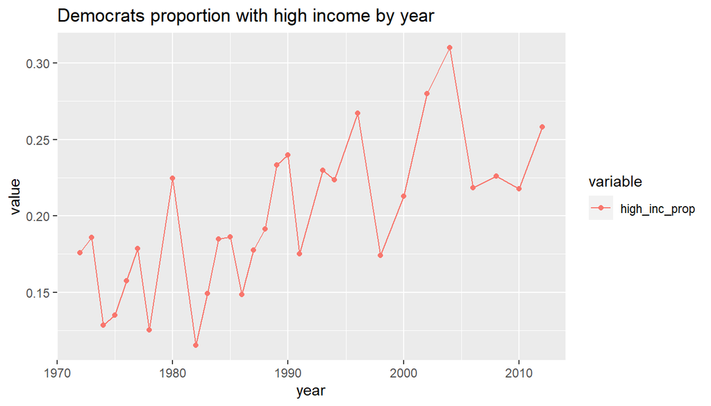

```r
#Convert democrats income level to proportion from the total number of democrats
democrats<-gss%>%
  filter((partyid == "Strong Democrat" |  partyid == "Not Str Democrat") & !is.na(coninc) )%>%
  mutate(high_income=ifelse(coninc >= high_income_mark,"high","low"))

democrats_prop<-democrats%>%
  group_by(year)%>%
  summarise(high_inc_prop=sum(high_income=="high")/n())

#Display democrats income level proportions by year
ggplot(democrats_prop, aes(x=year, y = value, color = variable)) +
    geom_line(aes(y = high_inc_prop, col = "high_inc_prop"))+
    geom_point(aes(y = high_inc_prop, col = "high_inc_prop"))+
    labs(title="Democrats proportion with high income by year")
```

**Interpretation for the sample: Proportion of democrats with high income grows**

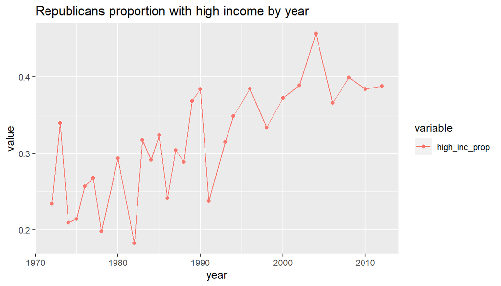

```r
#Convert democrats income level to proportion from the total number of democrats
republicans<-gss%>%
  filter((partyid == "Strong Republican" |  partyid == "Not Str Republican") & !is.na(coninc) )%>%
  mutate(high_income=ifelse(coninc >= high_income_mark,"high","low"))

republicans_prop<-republicans%>%
  group_by(year)%>%
  summarise(high_inc_prop=sum(high_income=="high")/n())

#Display democrats income level proportions by year
ggplot(republicans_prop, aes(x=year, y = value, color = variable)) +
    geom_line(aes(y = high_inc_prop, col = "high_inc_prop"))+
    geom_point(aes(y = high_inc_prop, col = "high_inc_prop"))+
    labs(title="Republicans proportion with high income by year")
```

**Interpretation for the sample: Proportion of republicans with high income grows**

### Lets see where is more pronounced high-income voters proportion

```r
both_parties_income_rates<-merge(democrats_prop, republicans_prop, by = c("year", "year"),suffixes = c(".dem",".rep"))
both_parties_income_rates
```

```
##    year high_inc_prop.dem high_inc_prop.rep
## 1  1972         0.1758087         0.2340426
## 2  1973         0.1858407         0.3395639
## 3  1974         0.1284722         0.2092199
## 4  1975         0.1351820         0.2142857
## 5  1976         0.1576271         0.2570423
## 6  1977         0.1784566         0.2677419
## 7  1978         0.1252205         0.1981707
## 8  1980         0.2247619         0.2937294
## 9  1982         0.1152369         0.1823899
## 10 1983         0.1493056         0.3172043
## 11 1984         0.1847390         0.2916667
## 12 1985         0.1861314         0.3238771
## 13 1986         0.1484230         0.2412791
## 14 1987         0.1775701         0.3041237
## 15 1988         0.1913215         0.2887139
## 16 1989         0.2331407         0.3683084
## 17 1990         0.2399103         0.3842239
## 18 1991         0.1751527         0.2376471
## 19 1993         0.2297297         0.3150685
## 20 1994         0.2236559         0.3485868
## 21 1996         0.2671312         0.3847242
## 22 1998         0.1740654         0.3338485
## 23 2000         0.2127660         0.3722871
## 24 2002         0.2798552         0.3887283
## 25 2004         0.3101045         0.4566713
## 26 2006         0.2183544         0.3661972
## 27 2008         0.2260062         0.3990930
## 28 2010         0.2178060         0.3840580
## 29 2012         0.2581144         0.3877551
```

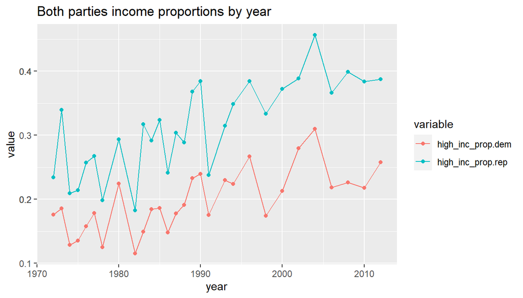

```r
#lets see all the ratio together while we
ggplot(both_parties_income_rates, aes(x=year, y = value, color = variable)) +
    geom_line(aes(y = high_inc_prop.dem, col = "high_inc_prop.dem"))+
    geom_point(aes(y = high_inc_prop.dem, col = "high_inc_prop.dem"))+
    geom_line(aes(y = high_inc_prop.rep, col = "high_inc_prop.rep"))+
    geom_point(aes(y = high_inc_prop.rep, col = "high_inc_prop.rep"))+
    scale_y_continuous(breaks = round(seq(0, 0.8, by = 0.05),1))+
    labs(title="Both parties income proportions by year")
```

**Interpretation for the sample: Proportion of republicans with high income is always higher throughout all the years**

## Part 4: Inference

Note, there is no CI for Chi Square independence test  
**So, this research will only include the hypothesis and Chi Square independence test**

### Hypothesis Test (Chi-Squared independence test)

H_0: There is no dependency between supporting one of two major parties and being rich (60k+ income)  
H_A: There is a dependency between supporting one of two major parties and being rich (60k+ income)

Explanatory variable: party  
Response variable: income

Note: Though it is presumably a ‘strange’ dependency: ‘particular party affiliation influences income’, considering the absence of the experiment and a control group, **no one can claim that there is ANY causality at all**, so, this direction of dependency has the same theoretical validity as an opposite direction: ‘income influences particular party affiliation’

One may claim, that the same rich party members meet at the same golf clubs and thus do create business connections and other conditions for income growth.

So,put aside the ‘chicken and eggs’ issue, in this Hypothesis we only test **the general presence of dependency (rich<->party affiliation) and causality is out of the scope**.

### Lets create unctions to compose chi-square tables for both parties

```r
filter_na_income_party <- function(year_param){
  partisans_income<-gss%>%
    filter(!is.na(coninc) & !is.na(partyid) & year==year_param)
  partisans_income
}

get_chi_table_income<- function(partisans_income, party){
    partisans_income<-partisans_income%>%
    mutate(high_income=ifelse(coninc >= high_income_mark, "high","na"))
    proportions_partisan<-partisans_income%>%
      summarise(rich_partisan=sum(being_partisan==party & high_income=="high"),
                rich_other=sum(being_partisan=="other" & high_income=="high"),
                total_rich=sum(high_income=="high"),
                not_rich_partisan=sum(being_partisan==party & high_income=="na"),
                not_rich_other=sum(being_partisan=="other" & high_income=="na"),
                total_not_rich=sum(high_income=="na"),
                total_rep=sum(being_partisan==party),
                total_other=sum(being_partisan=="other"),
                total_all=n())

    chi_table <- matrix(c(proportions_partisan$rich_partisan, proportions_partisan$rich_other,proportions_partisan$total_rich,
                    proportions_partisan$not_rich_partisan, proportions_partisan$not_rich_other, proportions_partisan$total_not_rich,
                    proportions_partisan$total_rep,proportions_partisan$total_other,proportions_partisan$total_all), ncol=3, byrow=TRUE)
    colnames(chi_table) <- c(party,'other','total')
    rownames(chi_table) <- c('rich','not_rich', 'total')
    chi_table <- as.table(chi_table)
    chi_table
}



get_chi_table_income_republicans <- function(year_param) {
  partisans_income<-filter_na_income_party(year_param)
  partisans_income<-partisans_income%>%
    mutate(being_partisan=ifelse(partyid == "Strong Republican" |  partyid == "Not Str Republican","republican","other"))
  get_chi_table_income(partisans_income,"republican")
}

get_chi_table_income_democrats <- function(year_param) {
  partisans_income<-filter_na_income_party(year_param)
  partisans_income<-partisans_income%>%
    mutate(being_partisan=ifelse(partyid == "Strong Democrat" |  partyid == "Not Str Democrat","democrat","other"))
  get_chi_table_income(partisans_income,"democrat")
}
```

### Here you can see example Chi-Square tables for each party for 1 selected year

```r
#Example(chi-table construction by year):
rep_income<-get_chi_table_income_republicans("1972")
rep_income
```

```
##          republican other total
## rich             77   220   297
## not_rich        252   920  1172
## total           329  1140  1469
```

```r
dem_income<-get_chi_table_income_democrats("1972")
dem_income
```

```
##          democrat other total
## rich          125   172   297
## not_rich      586   586  1172
## total         711   758  1469
```

### Lets create a function for p-value calculation

Note, returned is not only p-value, but a direction of discovered dependency:  
If, for example, there is a positive correlation between party affiliation and increased proportion of rich, it is direction=2.  
The negative correlation produces direction 1.  
Those directions we later need to construct visual presentation.

Note: This function also validates Chi-table population parameters

```r
getDependencyPValue <- function(party_income) {

  totalRichProp    <- party_income[1,3]/party_income[3,3]
  totalNotRichProp <- 1-totalRichProp


  pop_rich_partisan        <- party_income[3,1]*totalRichProp
  pop_not_reach_partisan   <- party_income[3,1]*totalNotRichProp
  pop_rich_other           <- party_income[3,2]*totalRichProp
  pop_not_rich_others      <- party_income[3,2]*totalNotRichProp


  tol = 1e-5# tolerance level for floats comparison

  ##Lets check that calculated population numbers are fit
  if(abs(pop_rich_partisan+pop_not_reach_partisan-party_income[3,1]) > tol){
    warning("Failed to conctruct expected population of partisans")
    stop()
  }
  if(abs(pop_rich_other+pop_not_rich_others-party_income[3,2]) > tol){
    warning("Failed to conctruct expected population of others")
    stop()
  }
  if(abs(pop_rich_partisan+pop_rich_other-party_income[1,3]) > tol){
    warning("Failed to conctruct expected population of rich")
    stop()
  }
  if(abs(pop_not_reach_partisan+pop_not_rich_others-party_income[2,3]) > tol){
    warning("Failed to conctruct expected population of not rich")
    stop()
  }

  Chi2<-((party_income[1,1]-pop_rich_partisan)**2/pop_rich_partisan+
       (party_income[2,1]-pop_not_reach_partisan)**2/pop_not_reach_partisan+
       (party_income[1,2]-pop_rich_other)**2/pop_rich_other+
       (party_income[2,2]-pop_not_rich_others)**2/pop_not_rich_others)

  DF=(2-1) * (2-1) # We always have 2 columns, 2 rows
  p_value=pchisq(Chi2, DF, lower.tail = FALSE)

  #the direction of the disproportion in rich partisans in observed data
  direction<-0 # by default there is no disproportion
  if(party_income[1,1]/party_income[3,1]<party_income[1,2]/party_income[3,2]){
      direction<-1 #partisans are less rich as all others
  }else if(party_income[1,1]/party_income[3,1]>party_income[1,2]/party_income[3,2]){
      direction<-2 #partisans are more rich as all others
  }

  annual_party_result <- list("pvalue" = p_value, "direction" = direction)
  return(annual_party_result)

}
```

### Example run of the function for 1 particular party for 1 particular year

```r
party_income<-get_chi_table_income_republicans("2012")
annual_party_result = getDependencyPValue(party_income)
pvalue=annual_party_result$pvalue
direction=annual_party_result$direction
pvalue
```

```
## [1] 2.208748e-06
```

```r
direction
```

```
## [1] 2
```

**Interpretation: For this year: 2012 p_value is << 0.05(H_o rejected), direction is 2, republicans do have visibly (statistically) increased proportion of rich among their voters**

### Lets prepare functions to run thus HT for all years for two parties

```r
years<-sort(unique(gss$year))
getPartyInfo <- function(years, party) {
  p_values<-vector("numeric", length(years))
  directions<-vector("numeric", length(years))
  index=0
  for(year in years) {
      party_income
      if(party=="democrats"){
         party_income<-get_chi_table_income_democrats(year)
      }else if(party=="republicans"){
         party_income<-get_chi_table_income_republicans(year)
      }
      annual_party_result = getDependencyPValue(party_income)
      pvalue=annual_party_result$pvalue
      direction=annual_party_result$direction
      p_values[index]<-pvalue
      directions[index]<-direction
      index <- index+1
  }
  party.info <- data.frame(years, p_values, directions)
  party.info
}

dems.info = getPartyInfo(years,"democrats")
reps.info = getPartyInfo(years,"republicans")
```

### Lets merge two parties together

```r
both_parties_chi_data<-merge(dems.info, reps.info, by = c("years", "years"),suffixes = c(".dem",".rep"))
both_parties_chi_data
```

```
##    years p_values.dem directions.dem p_values.rep directions.rep
## 1   1972 1.234213e-08              1 8.750371e-04              2
## 2   1973 4.788884e-03              1 1.321425e-02              2
## 3   1974 3.631385e-03              1 1.952465e-02              2
## 4   1975 1.330669e-03              1 4.772124e-03              2
## 5   1976 2.893850e-02              1 1.820912e-03              2
## 6   1977 3.503105e-02              1 5.117983e-03              2
## 7   1978 2.045338e-01              1 2.042186e-02              2
## 8   1980 1.315194e-03              1 3.443498e-02              2
## 9   1982 3.958904e-05              1 1.922817e-10              2
## 10  1983 4.623515e-02              1 5.678906e-05              2
## 11  1984 5.100515e-05              1 5.482605e-06              2
## 12  1985 2.764851e-03              1 2.970288e-03              2
## 13  1986 9.166263e-05              1 7.691232e-06              2
## 14  1987 2.461787e-03              1 4.726476e-03              2
## 15  1988 5.718363e-04              1 1.880825e-06              2
## 16  1989 1.312851e-03              1 2.732825e-06              2
## 17  1990 5.055481e-01              1 6.624684e-04              2
## 18  1991 4.307576e-02              1 2.128449e-03              2
## 19  1993 1.233611e-03              1 1.233084e-10              2
## 20  1994 2.246905e-02              1 1.263170e-09              2
## 21  1996 1.903003e-06              1 2.334874e-13              2
## 22  1998 1.929658e-03              1 5.482803e-15              2
## 23  2000 1.677461e-01              1 6.215695e-10              2
## 24  2002 1.935394e-03              1 1.122572e-12              2
## 25  2004 6.534394e-04              1 1.056946e-21              2
## 26  2006 1.233479e-04              1 1.332717e-10              2
## 27  2008 5.158252e-04              1 9.228709e-10              2
## 28  2010 1.695136e-02              1 2.208748e-06              2
## 29  2012 0.000000e+00              0 0.000000e+00              0
```

### Lets normalize values

1. p-values>0.05 converted to 0: no significance (no dependency found)  
2. p-values go through the log scaling to better show them in the graph  
3. Dependent on direction p-values changed to negative (direction=1) to show it better in the graph (In reality Chi Square distribution has no negative values, we know that!)

```r
both_parties_chi_data<-both_parties_chi_data%>%
  mutate(norm_dem_pvalue=ifelse(p_values.dem<0.05,log(p_values.dem),0))%>%
  mutate(norm_rep_pvalue=ifelse(p_values.rep<0.05,log(p_values.rep),0))

both_parties_chi_data<-both_parties_chi_data%>%
  mutate(signed_norm_dem_pvalue=ifelse(directions.dem==2,-norm_dem_pvalue,ifelse(directions.dem==1,norm_dem_pvalue,0)))%>%
  mutate(signed_norm_rep_pvalue=ifelse(directions.rep==2,-norm_rep_pvalue,ifelse(directions.rep==1,norm_rep_pvalue,0)))

both_parties_chi_data
```

```
##    years p_values.dem directions.dem p_values.rep directions.rep
## 1   1972 1.234213e-08              1 8.750371e-04              2
## 2   1973 4.788884e-03              1 1.321425e-02              2
## 3   1974 3.631385e-03              1 1.952465e-02              2
## 4   1975 1.330669e-03              1 4.772124e-03              2
## 5   1976 2.893850e-02              1 1.820912e-03              2
## 6   1977 3.503105e-02              1 5.117983e-03              2
## 7   1978 2.045338e-01              1 2.042186e-02              2
## 8   1980 1.315194e-03              1 3.443498e-02              2
## 9   1982 3.958904e-05              1 1.922817e-10              2
## 10  1983 4.623515e-02              1 5.678906e-05              2
## 11  1984 5.100515e-05              1 5.482605e-06              2
## 12  1985 2.764851e-03              1 2.970288e-03              2
## 13  1986 9.166263e-05              1 7.691232e-06              2
## 14  1987 2.461787e-03              1 4.726476e-03              2
```

[output cut: 75 more lines]

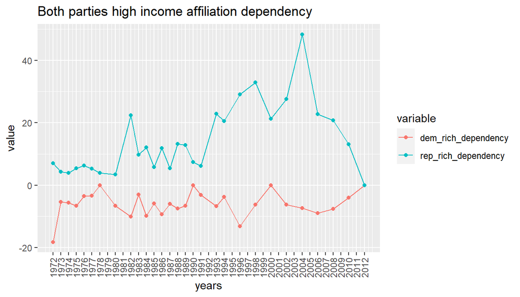

```r
ggplot(both_parties_chi_data, aes(x=years, y = value, color = variable)) +
    geom_line(aes(y = signed_norm_dem_pvalue, col = "dem_rich_dependency"))+
    geom_point(aes(y = signed_norm_dem_pvalue, col = "dem_rich_dependency"))+
    geom_line(aes(y = signed_norm_rep_pvalue, col = "rep_rich_dependency"))+
    geom_point(aes(y = signed_norm_rep_pvalue, col = "rep_rich_dependency"))+
    scale_x_continuous(breaks = round(seq(years[1], years[length(years)], by = 1),1))+
    labs(title="Both parties high income affiliation dependency")+
    theme(axis.text.x = element_text(angle = 90, vjust = 0.5, hjust=1))
```

But: According to surveys published in very recent years, this tendency seems to be minimized now.  
https://www.cnbc.com/2016/10/23/the-rich-vote-republican-maybe-not-this-time.html  
(Unfortunately we do not have latest years in the data to prove that)